# Solution_HC

## Solution - Hierarchical clustering

### Find clusters in a simulated sample.

**1)** Load data from the file: 'Ring_simulation.xlsx'. Make a scatter plot of the two variables.

Before starting the exercise, we first load the relevant packages and we also load some useful functions to solve the exercises (we expect to compute the Euclidean distance since it is an exercise on hierarchical clustering). We then load the data and make the plot.

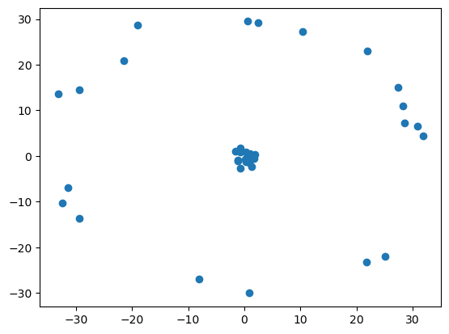

```python
import numpy as np
import pandas as pd
import matplotlib.pyplot as plt
import sys
import scipy.cluster.hierarchy as sc
import scipy.spatial.distance as sc_dist
from sklearn.metrics import silhouette_score

path = r'C:\Users\a_dufays\Dropbox\EDHEC\Courses\Data mining\Slides of the course\Topic 1 - Unsupervised learning on individuals\Data'

## Computation of the Euclidean distance of an (Nxd) array or a multivariate dataframe
## The Euclidean distance is computed over the *d* dimension (columns of the inputs)
## Inputs:
    ## x1 and x2: Two possibilities:
        ## np array (Nxd) or Nxd dataframe
        ## One dimensional array or a one dimensional dataframe
## Output:
    ## Euclidean distance of the datapoints (Array of dimension N if two dimensional otherwise scalar)
def Euclidean_dist(x1,x2):
    if(hasattr(x1, 'to_numpy')): ## Checking if the input is Numpy type or DataFrame type
        x1 = x1.to_numpy() ## If not Numpy type: we assume this is a dataframe.
        x2 = x2.to_numpy() ## If not Numpy type: we assume this is a dataframe.


    if(np.size(x1)!=np.size(x2)): ## Checking dimension
        sys.exit("Dimension issue")
    if(np.ndim(x1)<=1): ## If one dimensional array: Euclidean over the rows --> scalar
        euc_dist = np.sqrt(np.sum((x1-x2)**2))
    else: ## Nxd array --> Euclidean distance for each row (sum over the columns)
        euc_dist = np.sqrt(np.sum((x1-x2)**2,axis=1))

    return euc_dist


## Computation of Silhouette score using the hierarchical clustering approach
## Inputs:
    ## data: array of dataframe (NxK)
    ## method_name: 'single' (default), 'complete', 'average', 'weighted' and 'ward'
    ## nb_cluster_max: Numbers of cluster for which the Silhouette is computed (default 10)
## Output:
    ## 1d Vector of size nb_cluster_max: Silhouette score for 1 , 2 , ..., nb_cluster_max clusters
def compute_silhouette_score(data,method_name='single',nb_cluster_max=10):
    N = np.size(data,0)
    if(nb_cluster_max>=N):nb_cluster_max = N

    output_linkage = sc.linkage(data, method=method_name)
    print('Method used in the HC: ' + method_name)
    sil_score = np.zeros([nb_cluster_max])
    for i in range(1,nb_cluster_max):
        if(i<N-1):
            clust = sc.cut_tree(output_linkage,n_clusters=(i+1)).flatten()
            sil_score[i] = silhouette_score(data , clust)

    return sil_score

#############################
#### Loading the data
#############################
data = pd.read_excel(path + r'\Ring_simulation.xlsx',header=None) #customise according to your path directory
data.head()

#############################
#### Transforming the data into numpy type
#############################
y = data.to_numpy()

# Plot
plt.scatter(y[:,1],y[:,0])
plt.show()
```

We clearly observe two clusters exhibiting the same center (0,0). We shall see if the hierarchical clustering method can deal with this particular set of observations.

**2)** Compute the proximity matrix based on the Euclidean distance. What is the distance between the first observation and the second one ?

```python
dimension = np.shape(y)[1]
N = np.shape(y)[0]
Prox_mat = np.zeros([N,N])
for i in range(0,N):## Loop over the rows
    for j in range(0,N): ## Loop over the columns
        if(i!=j):Prox_mat[i,j] = Euclidean_dist(y[i,:],y[j,:]) ## When two observations are different (i!=j) then compute the distance


## dist 1-->2
print("Distance between the first and the second observations: " + str(round(Prox_mat[0,1],2)))
```

```
Distance between the first and the second observations: 2.4
```

Note that you can also compute the proximity matrix without using numpy. The following code provides two other solutions

```
1. Computing the proximity matrix using a dataframe.
2. Computing the proximity matrix using an in-built function of Python
```

```python
### Compute the proximity matrix using a dataframe.
dimension = np.shape(y)[1]
N = np.shape(y)[0]
Prox_mat1 = np.zeros([N,N])
for i in range(0,N):
    for j in range(0,N):
        if(i!=j):Prox_mat1[i,j] = Euclidean_dist(data.iloc[i],data.iloc[j])

## dist 1-->2
print("Dataframe - Distance between the first and the second observations: " + str(round(Prox_mat1[0,1],2)))

###########################################
#### Compute the proximity matrix using an in-built function of Python
###########################################
from scipy.spatial import distance_matrix
Prox_mat_py = distance_matrix(y,y)

## dist 1-->2
print("In-built function - Distance between the first and the second observations: " + str(round(Prox_mat_py[0,1],2)))
```

```
Dataframe - Distance between the first and the second observations: 2.4
In-built function - Distance between the first and the second observations: 2.4
```

**3)** Make a dendrogram using the single linkage method.

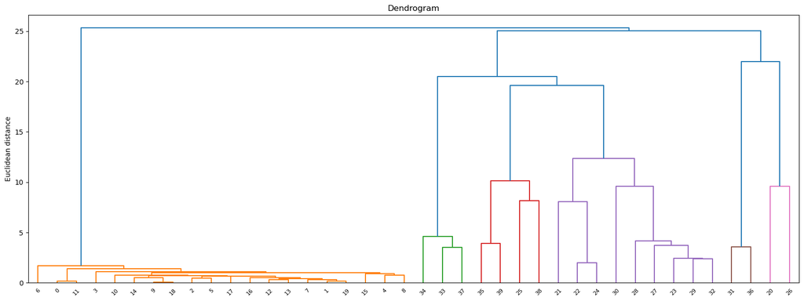

```python
###Dendrogram
plt.figure(figsize=(20, 7))
plt.title("Dendrograms")
sc.dendrogram(sc.linkage(y, method='single'))
plt.title('Dendrogram')
plt.ylabel('Euclidean distance')
plt.show()
```

We already observe that two clusters have been identified on the dendrogram. Let us compute the silhouette score to see if it gives evidence in favor of two clusters.

**4)** Compute the silhouette score for a number of clusters ranging from 1 to 10. Then, choose the optimal number of clusters. Comment your result.

```
Method used in the HC: single
```

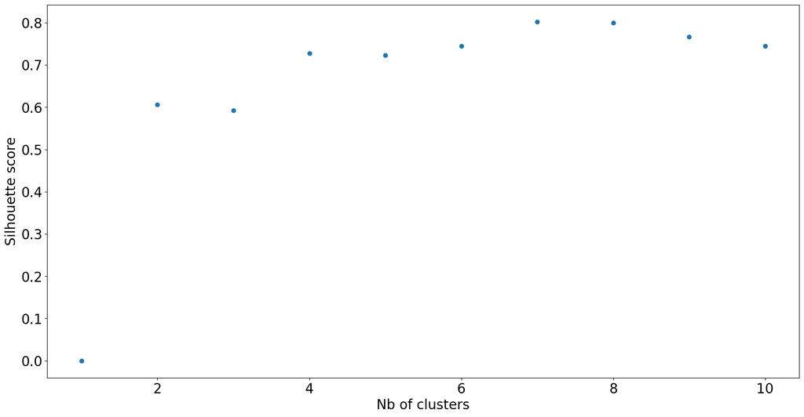

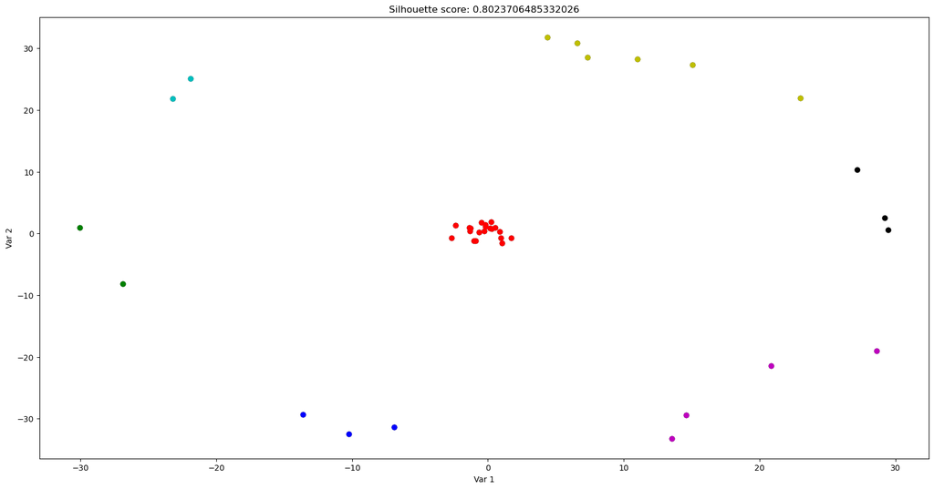

```python
### Computation of the Silhouette score for the first 10 clusters
max_K = 10
s_score = compute_silhouette_score(Prox_mat, method_name='single',nb_cluster_max=max_K)


plt.figure(figsize=(20, 10))
plt.plot(np.arange(1,max_K+1),s_score,'o')
plt.xlabel("Nb of clusters",fontsize=20)
plt.ylabel("Silhouette score",fontsize=20)
plt.tick_params(axis='both',labelsize=20)
plt.show()


##### Let us find which observations are in those clusters
K_max = np.argmax(s_score)+1
output_linkage = sc.linkage(y, method='single')
idx_best = sc.cut_tree(output_linkage,n_clusters=K_max) ## idx_best links every observation to a cluster

### Plotting the observation with a color which indicates in which cluster it belongs.

fig, ax = plt.subplots(figsize=(20, 10))
ax.scatter(y[:,0],y[:,1],color='black')
col = ['or','og','ok','oy','om','oc','ob']
for k in range(K_max):
    plt.plot(y[idx_best[:,0]==k,0],y[idx_best[:,0]==k,1],col[k])

plt.xlabel("Var 1")
plt.ylabel("Var 2")
plt.title("Silhouette score: " + str(s_score[K_max-1]))
plt.show()
```

The silhouette score does not work well for clusters with irregular shapes. As highlighted with this simulated dataset, it is clear that the dendrogram and the silhouette score provide contradictory conclusion. Ultimately, the choice of optimal number of clusters would depend on mixed evidence provided by the context, the dendrogram, the plot of the data and the silhouette score.

Using another distance metric would not solve the problem in this case since the silhouette score is designed to favor well-compact clusters.

```
Method used in the HC: complete
Method used in the HC: ward
```

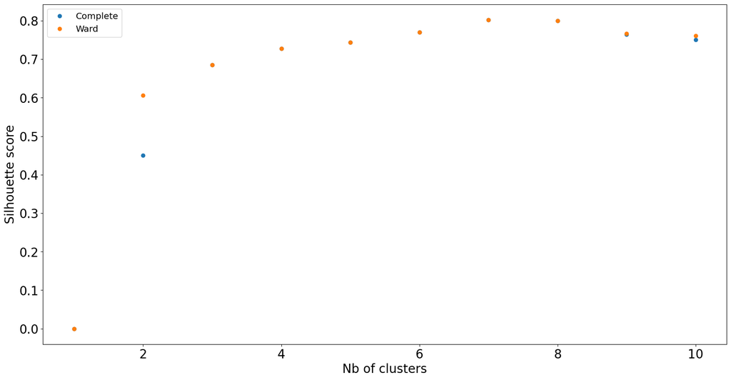

```python
### Computation of the silhouette for the first 10 clusters
max_K = 10
s_score_comp = compute_silhouette_score(Prox_mat, method_name='complete',nb_cluster_max=max_K)
s_score_ward = compute_silhouette_score(Prox_mat, method_name='ward',nb_cluster_max=max_K)


plt.figure(figsize=(20, 10))
plt.plot(np.arange(1,max_K+1),s_score_comp,'o')
plt.plot(np.arange(1,max_K+1),s_score_ward,'o')
plt.xlabel("Nb of clusters",fontsize=20)
plt.ylabel("Silhouette score",fontsize=20)
plt.legend(['Complete','Ward'],fontsize='x-large')
plt.tick_params(axis='both',labelsize=20)
plt.show()
```

### Harry potter characters

The characteristics of some characters from the Goblet of fire are stored in 'Trumps_card_Harry_potter_Goblet_fire.xlsx'. We will use the hierarchical clustering approach to see if the sorting hat did a great job when it chose the Hogwart's houses for those characters. First of all, load the data and focus on the following variables: Magic, Cunning, Courage, Wisdom and Temper.

**1)** Standardized the variables since the scales are different (see for instance Magic and Temper).

In the following, we load and the standardized the data.

```python
#### Loading the data
data = pd.read_excel(path + r'\Trumps_card_Harry_potter_Goblet_fire.xlsx') #customise according to your path directory
data.head()

################
#### Transforming the data into numpy type
################
y = data[data.columns[1:6]].to_numpy()

################
#### Standardizing the data
################
dimension = np.shape(y)[1]
N = np.shape(y)[0]
y_std = (y - np.mean(y,axis=0))/np.std(y,axis=0,ddof=1)
```

**2)** Compute the proximity matrix based on the Euclidean distance. What is the distance between Snape and Albus Dumbledore ?

```python
### Computing the proximity matrix
Prox_mat = np.zeros([N,N])
for i in range(N):
    for j in range(N):
        if(i!=j):Prox_mat[i,j] = Euclidean_dist(y_std[i,:],y_std[j,:])


print("Distance between Snape and Dumbledore: " + str(round(Prox_mat[0,6],2)))
```

```
Distance between Snape and Dumbledore: 3.44
```

**3)** Make a dendrogram using the *complete* method (change 'single' by 'complete' in Python). Comment briefly the dendrogram.

[figure not shown]

```python
### Creating the labels for the dendrogram
list_label = list(data[data.columns[0]])

# Plot dendrogram
plt.figure(figsize=(20, 7))
plt.title("Dendrograms")
sc.dendrogram(sc.linkage(y_std, method='complete'),labels=list_label,leaf_rotation=45)
plt.title('Dendrogram')
plt.ylabel('Distance')
plt.show()
```

Interestingly, we observe specific clusters that make sense historywise. For instance, the twins (Weasley) are the closest observations in the sample. We also observe that most of the Slytherins are categorized together (we still have doubt about the house of Snape).

**4)** In the book, the house of Rita Skeeter is not mentioned. According to the dendrogram, in which house do you think she belongs ?

According to the dendrogram, she would belong to the Slytherin's house. The first two clusters to which she belongs are {Draco Malefoy} and then {Draco Malefoy, Voldemort, Lucius Malefoy}.

**5)** Compute the silhouette score for all possible numbers of clusters and choose an optimal number of clusters.

```
Method used in the HC: single
Method used in the HC: complete
```

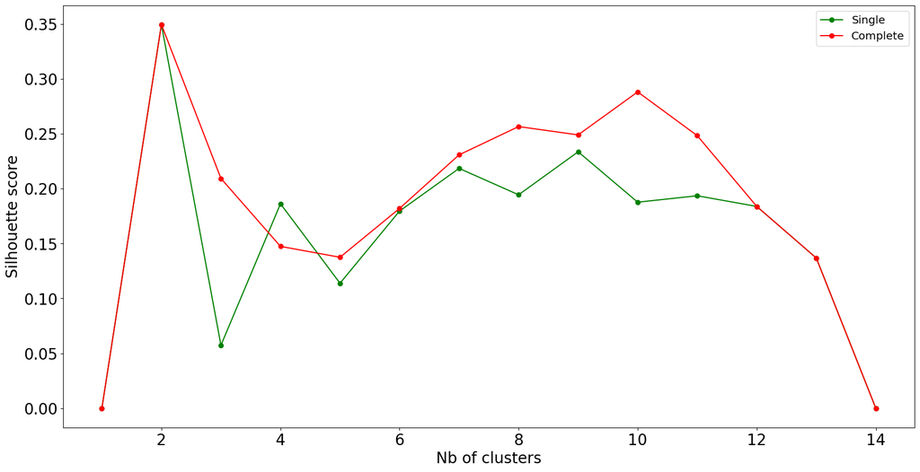

[figure not shown]

```python
## Computing the silhouette for all the observations
s_score = compute_silhouette_score(y_std, method_name='single',nb_cluster_max=N)
s_score_comp = compute_silhouette_score(y_std, method_name='complete',nb_cluster_max=N)

## Making a plot of the Silhouette
plt.figure(figsize=(20, 10))
plt.plot(np.arange(1,N+1),s_score,'-og')
plt.plot(np.arange(1,N+1),s_score_comp,'-or')
plt.xlabel("Nb of clusters",fontsize=20)
plt.ylabel("Silhouette score",fontsize=20)
plt.legend(['Single','Complete'],fontsize='x-large')
plt.tick_params(axis='both',labelsize=20)

## For K=2
output_linkage = sc.linkage(y_std, method='single')
clust = sc.cut_tree(output_linkage,n_clusters=2)


# Plot dendrogram
plt.figure(figsize=(20, 7))
plt.title("Dendrograms")
sc.dendrogram(sc.linkage(y_std, method='single'),labels=list_label,leaf_rotation=45)
plt.title('Dendrogram')
plt.ylabel('Euclidean distance')
plt.show()
```

Both distance metrics agree with 2 clusters. It seems that Dumbledore is an outstanding wizard compared to all the other wizards.

### Clustering models based on their predictions.

We consider the predictions for 11 returns of 66 different financial models. These predictions have been done in February 18, 2021 and are the expected returns if a financial crisis occurs in the following days. The data are stored in 'Prediction_Models.xlsx'. We will use the hierarchical clustering approach to detect which models produce similar forecasts.

**1)** Standardize the variables.

```python
### Loading the data
data = pd.read_excel(path + r'\Prediction_Models.xlsx') #customise according to your path directory
data.head()

################
#### Transforming the data into numpy type
################
y = data[data.columns[1:]].to_numpy()


################
#### Standardizing the data
################
dimension = np.shape(y)[1]
N = np.shape(y)[0]
y_std = (y - np.mean(y,axis=0))/np.std(y,axis=0,ddof=1)
```

**2)** Compute the proximity matrix based on the Euclidean distance.

```python
## Computing the proximity matrix using the standardized data
Prox_mat = np.zeros([N,N])
for i in range(0,N):
    for j in range(0,N):
        if(i!=j):Prox_mat[i,j] = Euclidean_dist(y_std[i,:],y_std[j,:])
```

**3)** Make a dendrogram using the single-linkage method .

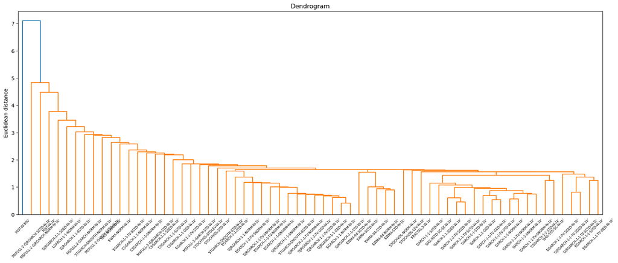

```python
## create labels
list_label = list(data[data.columns[0]])


# Plot dendrogram
plt.figure(figsize=(20, 7))
plt.title("Dendrograms")
sc.dendrogram(sc.linkage(y_std, method='single'),labels=list_label,leaf_rotation=45)
plt.title('Dendrogram')
plt.ylabel('Euclidean distance')
plt.show()
```

We clearly see the limit of the dendrogram. When we have a lot of observations, it is difficult to make sense of this visualization.

**4)** Compute the silhouette score for the first 30 clusters and choose an optimal number of clusters.

```
Method used in the HC: complete
```

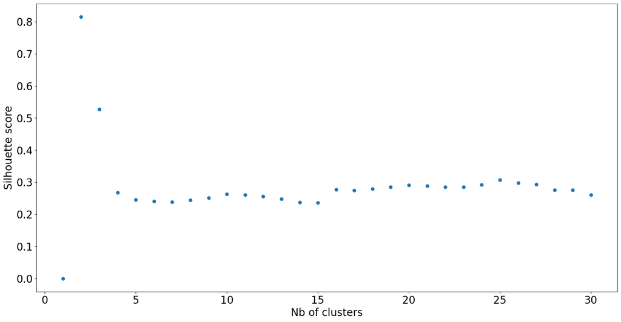

```
Similar models are:
'CSGARCH-1-1-GED-W-1k'
'CSGARCH-1-1-NORM-W-1k'
'CSGARCH-1-1-SGED-W-1k'
'CSGARCH-1-1-SNORM-W-1k'
'CSGARCH-1-1-SSTD-W-1k'
'CSGARCH-1-1-STD-W-1k'
'EGARCH-1-1-NORM-W-1k'
'EGARCH-1-1-SNORM-W-1k'
'EGARCH-1-1-SSTD-W-1k'
'EGARCH-1-1-STD-W-1k'
'EGARCH-1-1-TV-GED-W-1k'
'EGARCH-1-1-TV-NORM-W-1k'
'EGARCH-1-1-TV-SGED-W-1k'
'EGARCH-1-1-TV-SNORM-W-1k'
'EGARCH-1-1-TV-SSTD-W-1k'
'EGARCH-1-1-TV-STD-W-1k'
'EWMA-94-NORM-W-1k'
'EWMA-94-SSTD-W-1k'
'EWMA-94-STD-W-1k'
'EWMA-NORM-W-1k'
'EWMA-SSTD-W-1k'
'EWMA-STD-W-1k'
'FRACTAL-5-W-1k'
'GARCH-1-1-GED-W-1k'
'GARCH-1-1-NORM-W-1k'
'GARCH-1-1-SGED-W-1k'
'GARCH-1-1-SNORM-W-1k'
'GARCH-1-1-SSTD-W-1k'
'GARCH-1-1-STD-W-1k'
'GARCH-1-1-TV-GED-W-1k'
'GARCH-1-1-TV-NORM-W-1k'
'GARCH-1-1-TV-SGED-W-1k'
'GARCH-1-1-TV-SNORM-W-1k'
'GARCH-1-1-TV-SSTD-W-1k'
'GARCH-1-1-TV-STD-W-1k'
'GAS-NORM-W-1k'
'GAS-SSTD-SC-SK-W-1k'
'GAS-STD-SC-W-1k'
'GJRGARCH-1-1-GED-W-1k'
```

[output cut: 11 more lines]

```
'HIST-W-1k'
'LGARCH-1-1-NORM-W-1k'
'MSFULL-2-GARCH-NORM-W-1k'
'MSFULL-2-GARCH-SSTD-W-1k'
'MSFULL-2-GARCH-STD-W-1k'
'MSFULL-2-GJRGARCH-NORM-W-1k'
'MSFULL-2-GJRGARCH-SSTD-W-1k'
'MSFULL-2-GJRGARCH-STD-W-1k'
'STGARCH-SMOOTH-NORM-W-1k'
'STGARCH-SMOOTH-SSTD-W-1k'
'STGARCH-SMOOTH-STD-W-1k'
'STOCHVOL-LEV-W-1k'
'STOCHVOL-NORM-W-1k'
'STOCHVOL-STD-W-1k'
'STOCHVOL-STDLEV-W-1k'
```

```python
### Computing silhouette for the first 30 clusters
max_K = 30
s_score = compute_silhouette_score(Prox_mat,'complete',max_K)

### Plotting silhouette
plt.figure(figsize=(20, 10))
plt.scatter(np.arange(1,max_K+1),s_score)
plt.xlabel("Nb of clusters",fontsize=20)
plt.ylabel("Silhouette score",fontsize=20)
plt.tick_params(axis='both',labelsize=20)
plt.show()

## According to the graph, we could choose K = 2
output_linkage = sc.linkage(y_std, method='single')
K = 2
idx_best = sc.cut_tree(output_linkage,n_clusters=K)

count = np.zeros([K,1])
for k in range(0,K):
    count[k] = np.sum(idx_best[:,0]==k)

index_max = np.argmax(count)
print("Similar models are:")
for i in range(0,N):
    if(idx_best[i,0]==index_max):print(list_label[i])
```

#### Congressman's votes.

In the csv file 'Votes_Congressmen.csv', you will find votes for most of the U.S. House of representatives Congressmen on 16 key votes that took place in 1984. In this exercise, we suppose that we are Lobbyists seeking for congressmen that could be influenced as they do not always follow the official position of their party.

**1)** Load the data and convert every vote into a dummy variable. To do so, replace the 'y' vote with one and the 'n' vote with the value 0. How many congressmen have voted in favor of the first question ?

We start by loading the data and transforming the votes into dummy variables.

```python
##########################
### Loading the data
##########################
path = "C:/Users/a_dufays/Dropbox/EDHEC/Courses/Data mining/Slides of the course/Topic 1 - Unsupervised learning on individuals/Data/"
df_clear = pd.read_csv(path + "Votes_Congressmen.csv",sep=',') #customise according to your path directory

##########################
### Replacing the 'y' and 'n' with their corresponding values
##########################
df_clear = df_clear.replace('y',1)
df_clear = df_clear.replace('n',0)

##########################
### Converting into numpy types the votes and the Democrat dummy
##########################
X = df_clear[df_clear.columns[1:]].to_numpy()
df_Dum = pd.get_dummies(df_clear[df_clear.columns[0]])
Democrat = df_Dum['democrat'].to_numpy()
```

```python
### Number of congressmen:
print("Number of congressmen in favor of the first question : " + str(df_clear['Q1'].sum()))
## Equivalent to
print("Number of congressmen in favor of the first question : " + str(np.sum(X[:,0])))
```

```
Number of congressmen in favor of the first question : 96
Number of congressmen in favor of the first question : 96
```

**2)** Using the Euclidean distance and the maximum linkage clustering criterion (which corresponds to 'complete' in Python), apply the hierarchical clustering approach and make a dendrogram of the congressmen. Cut the data into two clusters. How many Democrat congressmen do you have in each cluster ?

First, we make the dendrogram. Since there are many congressmen, we will see that the dendrogram is difficult to interpret.

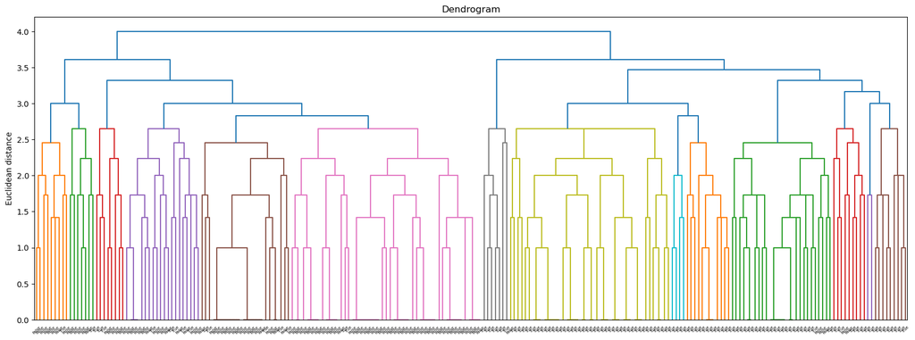

```python
###########################
### Computing the proximity matrix
###########################
N = np.shape(X)[0]
dimension = np.shape(X)[1]
Prox_mat = np.zeros([N,N])
for i in range(0,N):
    for j in range(0,N):
        if(i!=j):Prox_mat[i,j] = Euclidean_dist(X[i,:],X[j,:])

## create labels
list_label= list(Democrat)


# Plot dendrogram
plt.figure(figsize=(20, 7))
plt.title("Dendrograms")
sc.dendrogram(sc.linkage(X, method='complete'),labels=list_label,leaf_rotation=45)
plt.title('Dendrogram')
plt.ylabel('Euclidean distance')
plt.show()
```

Looking at the dendrogram, we see its limit as we do have too many observations to visualize them on the Graphic. We are now ready to cut the dendrogram into two parts and count the number of Democrats in each cluster.

```python
#############################
### Cutting the dendrogram
#############################
output_linkage = sc.linkage(X, method='complete')
clust = sc.cut_tree(output_linkage,n_clusters=2)

nb_Demo = pd.DataFrame(np.array([np.sum(Democrat[clust[:,0]==0]),np.sum(Democrat[clust[:,0]==1])],ndmin=2),columns=['Cluster 1','Cluster 2'], index=['Nb Democrat'])
print(nb_Demo)
```

```
             Cluster 1  Cluster 2
Nb Democrat         17        107
```

Interestingly, we have identified the cluster with a clear majority of Democrat. As a Lobbyist, we could be interested in the 17 Democrats from the first cluster as they seem to sometimes vote differently from their political party line.